# ASSIGNMENT3

2023-10-31

```r
library(ggplot2)
```

```r
college <- read.csv2("college.csv", header = TRUE, sep = ",")
summary(college)
```

```
##     school            Private           Accept.pct           Elite10
##  Length:777         Length:777         Length:777         Min.   :0.0000
##  Class :character   Class :character   Class :character   1st Qu.:0.0000
##  Mode  :character   Mode  :character   Mode  :character   Median :0.0000
##                                                           Mean   :0.1004
##                                                           3rd Qu.:0.0000
##                                                           Max.   :1.0000
##   F.Undergrad     P.Undergrad         Outstate       Room.Board
##  Min.   :  139   Min.   :    1.0   Min.   : 2340   Min.   :1780
##  1st Qu.:  992   1st Qu.:   95.0   1st Qu.: 7320   1st Qu.:3597
##  Median : 1707   Median :  353.0   Median : 9990   Median :4200
##  Mean   : 3700   Mean   :  855.3   Mean   :10441   Mean   :4358
##  3rd Qu.: 4005   3rd Qu.:  967.0   3rd Qu.:12925   3rd Qu.:5050
##  Max.   :31643   Max.   :21836.0   Max.   :21700   Max.   :8124
##      Books           Personal         PhD            Terminal
##  Min.   :  96.0   Min.   : 250   Min.   :  8.00   Min.   : 24.0
##  1st Qu.: 470.0   1st Qu.: 850   1st Qu.: 62.00   1st Qu.: 71.0
##  Median : 500.0   Median :1200   Median : 75.00   Median : 82.0
##  Mean   : 549.4   Mean   :1341   Mean   : 72.66   Mean   : 79.7
##  3rd Qu.: 600.0   3rd Qu.:1700   3rd Qu.: 85.00   3rd Qu.: 92.0
##  Max.   :2340.0   Max.   :6800   Max.   :103.00   Max.   :100.0
##   S.F.Ratio          perc.alumni        Expend        Grad.Rate
##  Length:777         Min.   : 0.00   Min.   : 3186   Min.   : 10.00
##  Class :character   1st Qu.:13.00   1st Qu.: 6751   1st Qu.: 53.00
##  Mode  :character   Median :21.00   Median : 8377   Median : 65.00
##                     Mean   :22.74   Mean   : 9660   Mean   : 65.46
##                     3rd Qu.:31.00   3rd Qu.:10830   3rd Qu.: 78.00
##                     Max.   :64.00   Max.   :56233   Max.   :118.00
```

```r
college$Accept.pct = as.numeric(college$Accept.pct)
college$S.F.Ratio = as.numeric(college$S.F.Ratio)
```

# Problem 1

Apply regression analysis techniques to analyze the relationship among the observed variables and build a model to predict Graduation Rates (Grad.Rate). Answer the following questions:

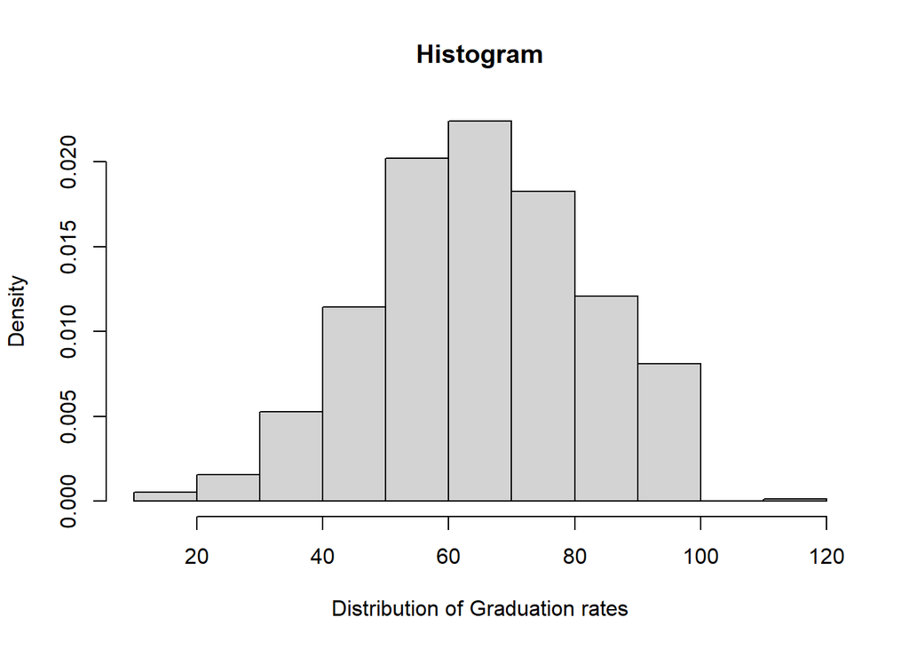

```r
hist(college$Grad.Rate, xlab="Distribution of Graduation rates", prob=TRUE, main="Histogram")
```

Observing above histogram we can say that data is normally distributed so no need of transformation.

2. Create scatterplots for Grad.Rate vs each of the independent variables. What conclusions can you draw about the relationships between Grad.Rate and the independent variables? (No need to include the scatterplots in your submission, but you can use correlation analysis)

```r
correlation = cor(college[ ,sapply(college,is.numeric)])
correlation["Grad.Rate", ]
```

```
##   Accept.pct      Elite10  F.Undergrad  P.Undergrad     Outstate   Room.Board
## -0.286971504  0.348732550 -0.078773129 -0.257000991  0.571289928  0.424941541
##        Books     Personal          PhD     Terminal    S.F.Ratio  perc.alumni
##  0.001060894 -0.269343964  0.305037850  0.289527232 -0.306710405  0.490897562
##       Expend    Grad.Rate
##  0.390342696  1.000000000
```

Here we observe that, Elite10,Outstate, Room.Board,Books, PHD, Terminal. perc.alumni, expend are positively correlated with Grad.Rate while others are negatively correlated i.e. F.Undergrad , P.Undergrad and Personal. Outstate and Grad.Rate are postively strongly correlated out of all.

3. Build boxplots to evaluate if graduation rates vary by university type (private vs public) and by status (elite vs not elite). Discuss your findings

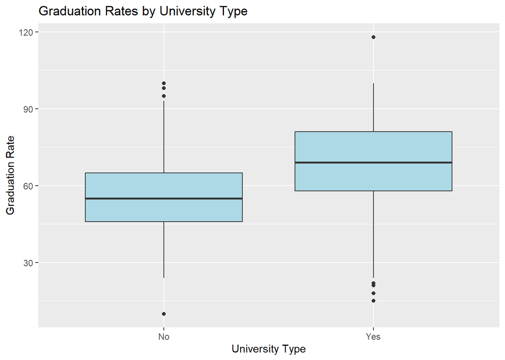

```r
ggplot(college, aes(x = Private, y = Grad.Rate)) +
  geom_boxplot(fill = "lightblue") +
  labs(x = "University Type", y = "Graduation Rate") +
  ggtitle("Graduation Rates by University Type")
```

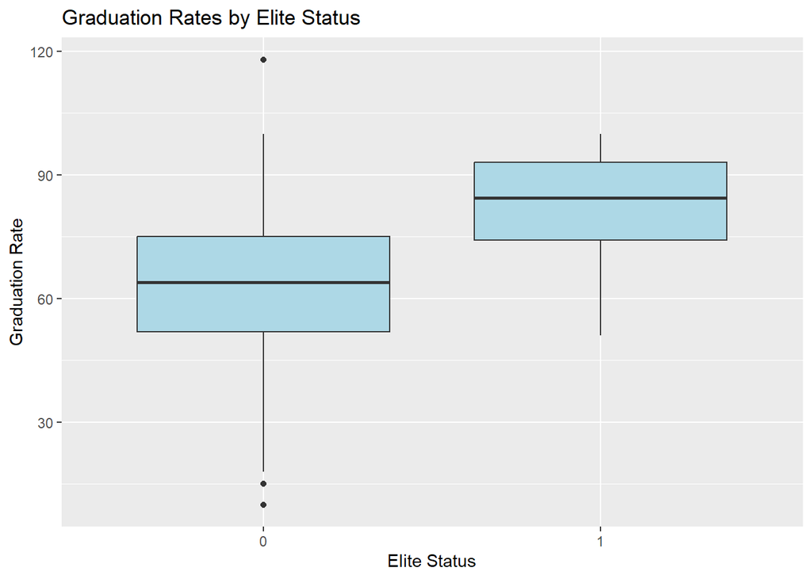

```r
ggplot(college, aes(x = as.factor(Elite10), y = Grad.Rate)) +
  geom_boxplot(fill = "lightblue") +
  labs(title = "Graduation Rates by Elite Status",
       x = "Elite Status",
       y = "Graduation Rate")
```

4. Fit a full model (with all independent variables) to predict Grad.Rate

```r
data = college[ , -which(names(college) == "school")]
```

```r
college_fit <- lm(Grad.Rate ~ ., data)
summary(college_fit)
```

```
##
## Call:
## lm(formula = Grad.Rate ~ ., data = data)
##
## Residuals:
##     Min      1Q  Median      3Q     Max
## -46.200  -6.777  -0.707   7.217  57.907
##
## Coefficients:
##               Estimate Std. Error t value Pr(>|t|)
## (Intercept)  5.140e+01  6.124e+00   8.393 2.30e-16 ***
## PrivateYes   4.620e+00  1.722e+00   2.683  0.00746 **
## Accept.pct  -1.811e+01  3.843e+00  -4.712 2.91e-06 ***
## Elite10      4.017e+00  2.003e+00   2.005  0.04527 *
## F.Undergrad  6.809e-04  1.429e-04   4.767 2.24e-06 ***
## P.Undergrad -1.956e-03  3.904e-04  -5.009 6.80e-07 ***
## Outstate     1.235e-03  2.286e-04   5.401 8.88e-08 ***
## Room.Board   1.667e-03  5.944e-04   2.805  0.00517 **
## Books       -2.524e-03  2.966e-03  -0.851  0.39511
## Personal    -1.718e-03  7.781e-04  -2.208  0.02753 *
## PhD          1.306e-01  5.621e-02   2.324  0.02037 *
## Terminal    -7.284e-02  6.257e-02  -1.164  0.24469
## S.F.Ratio    1.003e-03  1.619e-01   0.006  0.99506
## perc.alumni  3.092e-01  4.839e-02   6.390 2.89e-10 ***
## Expend      -4.365e-04  1.518e-04  -2.875  0.00415 **
## ---
## Signif. codes:  0 '***' 0.001 '**' 0.01 '*' 0.05 '.' 0.1 ' ' 1
##
## Residual standard error: 12.92 on 762 degrees of freedom
## Multiple R-squared:  0.4448, Adjusted R-squared:  0.4346
## F-statistic: 43.61 on 14 and 762 DF,  p-value: < 2.2e-16
```

About 44.48% variation is shown in graduation rates by the model. The Adjusted R-squared is 43.46% which is slightly lower. The model is said to be statistically significant with F-statistics of 43.61 and low p-value suggest that at least one predictor is significantly affecting the grad rate.

5. Does multi-collinearity seem to be a problem here? What is your evidence? Compute and analyze the VIF statistics.

```r
library(car)
stat<- vif(college_fit)
stat
```

```
##     Private  Accept.pct     Elite10 F.Undergrad P.Undergrad    Outstate
##    2.739521    1.486633    1.687903    2.233117    1.643393    3.935059
##  Room.Board       Books    Personal         PhD    Terminal   S.F.Ratio
##    1.976762    1.115823    1.290983    3.917716    3.946581    1.909722
## perc.alumni      Expend
##    1.672367    2.922643
```

There is no multicollinearity seen from the statistics as all the value is <5 which is not a problem. This suggests that the regression coefficients are reliable, and the model is well-suited for understanding the factors influencing graduation rates.

6. Apply TWO variable selection procedures to find an optimal subset of independent variables to predict Grad.Rate. You can choose any two procedures among the ones we learned in class: backward selection, forward selection, adj-R2 , Cp, stepwise, press.

```r
step(college_fit, direction = "backward")
```

```
## Start:  AIC=3990.75
## Grad.Rate ~ Private + Accept.pct + Elite10 + F.Undergrad + P.Undergrad +
##     Outstate + Room.Board + Books + Personal + PhD + Terminal +
##     S.F.Ratio + perc.alumni + Expend
##
##               Df Sum of Sq    RSS    AIC
## - S.F.Ratio    1       0.0 127126 3988.8
## - Books        1     120.8 127247 3989.5
## - Terminal     1     226.1 127352 3990.1
## <none>                     127126 3990.8
## - Elite10      1     671.0 127797 3992.8
## - Personal     1     813.4 127939 3993.7
## - PhD          1     901.2 128027 3994.2
## - Private      1    1200.9 128327 3996.1
## - Room.Board   1    1312.3 128438 3996.7
## - Expend       1    1379.4 128505 3997.1
## - Accept.pct   1    3704.3 130830 4011.1
## - F.Undergrad  1    3790.8 130917 4011.6
## - P.Undergrad  1    4185.8 131312 4013.9
## - Outstate     1    4866.1 131992 4017.9
## - perc.alumni  1    6812.2 133938 4029.3
##
## Step:  AIC=3988.75
## Grad.Rate ~ Private + Accept.pct + Elite10 + F.Undergrad + P.Undergrad +
##     Outstate + Room.Board + Books + Personal + PhD + Terminal +
##     perc.alumni + Expend
##
##               Df Sum of Sq    RSS    AIC
## - Books        1     120.8 127247 3987.5
## - Terminal     1     226.3 127352 3988.1
## <none>                     127126 3988.8
## - Elite10      1     671.0 127797 3990.8
## - Personal     1     818.0 127944 3991.7
## - PhD          1     903.9 128030 3992.3
## - Private      1    1227.8 128354 3994.2
## - Room.Board   1    1312.3 128438 3994.7
## - Expend       1    1642.3 128768 3996.7
## - Accept.pct   1    3734.1 130860 4009.2
## - F.Undergrad  1    3854.2 130980 4010.0
## - P.Undergrad  1    4186.5 131313 4011.9
```

[output cut: 25 more lines]

```
##     Outstate + Room.Board + Personal + PhD + perc.alumni + Expend
##
##               Df Sum of Sq    RSS    AIC
## <none>                     127521 3987.2
## - Elite10      1     672.6 128194 3989.3
## - PhD          1     861.3 128382 3990.4
## - Personal     1     946.5 128467 3990.9
## - Room.Board   1    1135.3 128656 3992.1
## - Private      1    1329.5 128851 3993.2
## - Expend       1    1719.0 129240 3995.6
## - Accept.pct   1    3655.7 131177 4007.1
## - F.Undergrad  1    3680.7 131202 4007.3
## - P.Undergrad  1    4219.0 131740 4010.5
## - Outstate     1    4773.9 132295 4013.7
## - perc.alumni  1    6758.1 134279 4025.3
```

```
##
## Call:
## lm(formula = Grad.Rate ~ Private + Accept.pct + Elite10 + F.Undergrad +
##     P.Undergrad + Outstate + Room.Board + Personal + PhD + perc.alumni +
##     Expend, data = data)
##
## Coefficients:
## (Intercept)   PrivateYes   Accept.pct      Elite10  F.Undergrad  P.Undergrad
##   4.840e+01    4.770e+00   -1.778e+01    4.022e+00    6.631e-04   -1.963e-03
##    Outstate   Room.Board     Personal          PhD  perc.alumni       Expend
##   1.215e-03    1.534e-03   -1.820e-03    8.424e-02    3.060e-01   -4.465e-04
```

```r
base = lm(Grad.Rate ~ 1, data = data)
step(base , scope = list(upper = college_fit,lower = ~1),direction = "forward")
```

```
## Start:  AIC=4419.97
## Grad.Rate ~ 1
##
##               Df Sum of Sq    RSS    AIC
## + Outstate     1     74732 154245 4115.0
## + perc.alumni  1     55179 173798 4207.7
## + Room.Board   1     41348 187630 4267.2
## + Expend       1     34889 194089 4293.5
## + Elite10      1     27847 201130 4321.2
## + Private      1     25876 203102 4328.8
## + S.F.Ratio    1     21540 207437 4345.2
## + PhD          1     21306 207671 4346.1
## + Terminal     1     19194 209783 4353.9
## + Accept.pct   1     18857 210120 4355.2
## + Personal     1     16611 212366 4363.5
## + P.Undergrad  1     15124 213853 4368.9
## + F.Undergrad  1      1421 227556 4417.1
## <none>                     228977 4420.0
## + Books        1         0 228977 4422.0
##
## Step:  AIC=4115
## Grad.Rate ~ Outstate
##
##               Df Sum of Sq    RSS    AIC
## + perc.alumni  1    9444.9 144800 4067.9
## + Accept.pct   1    5420.0 148825 4089.2
## + Elite10      1    3957.2 150288 4096.8
## + P.Undergrad  1    3079.0 151166 4101.3
## + Personal     1    2438.8 151807 4104.6
## + PhD          1    1995.9 152250 4106.9
## + Room.Board   1    1048.3 153197 4111.7
## + Terminal     1     875.4 153370 4112.6
## + F.Undergrad  1     475.1 153770 4114.6
## <none>                     154245 4115.0
## + Private      1     137.7 154108 4116.3
## + Books        1     102.5 154143 4116.5
## + S.F.Ratio    1      34.8 154211 4116.8
## + Expend       1      15.0 154230 4116.9
##
## Step:  AIC=4067.9
```

[output cut: 127 more lines]

```
## <none>                   128194 3989.3
## + Terminal   1    281.91 127912 3989.5
## + Books      1    162.15 128031 3990.3
## + S.F.Ratio  1      0.05 128194 3991.3
##
## Step:  AIC=3987.16
## Grad.Rate ~ Outstate + perc.alumni + Accept.pct + P.Undergrad +
##     F.Undergrad + Room.Board + Expend + Personal + Private +
##     PhD + Elite10
##
##             Df Sum of Sq    RSS    AIC
## <none>                   127521 3987.2
## + Terminal   1   274.173 127247 3987.5
## + Books      1   168.656 127352 3988.1
## + S.F.Ratio  1     0.114 127521 3989.2
```

```
##
## Call:
## lm(formula = Grad.Rate ~ Outstate + perc.alumni + Accept.pct +
##     P.Undergrad + F.Undergrad + Room.Board + Expend + Personal +
##     Private + PhD + Elite10, data = data)
##
## Coefficients:
## (Intercept)     Outstate  perc.alumni   Accept.pct  P.Undergrad  F.Undergrad
##   4.840e+01    1.215e-03    3.060e-01   -1.778e+01   -1.963e-03    6.631e-04
##  Room.Board       Expend     Personal   PrivateYes          PhD      Elite10
##   1.534e-03   -4.465e-04   -1.820e-03    4.770e+00    8.424e-02    4.022e+00
```

From the above Two variable selection procedures(Backward and Forward), the minimum step AIC from both the procedure is AIC=3987.16.

7. Fit a final regression model M1 for Grad.Rate based on the results in f). Explain your choice. Write down the expression of the estimated model M1

```r
M1 = lm(Grad.Rate ~ Outstate + perc.alumni + Accept.pct +
    P.Undergrad + F.Undergrad + Room.Board + Expend + Personal +
    Private + PhD + Elite10, data = data)
summary(M1)
```

```
##
## Call:
## lm(formula = Grad.Rate ~ Outstate + perc.alumni + Accept.pct +
##     P.Undergrad + F.Undergrad + Room.Board + Expend + Personal +
##     Private + PhD + Elite10, data = data)
##
## Residuals:
##     Min      1Q  Median      3Q     Max
## -45.085  -6.932  -0.775   7.325  57.598
##
## Coefficients:
##               Estimate Std. Error t value Pr(>|t|)
## (Intercept)  4.840e+01  4.621e+00  10.475  < 2e-16 ***
## Outstate     1.215e-03  2.270e-04   5.352 1.15e-07 ***
## perc.alumni  3.060e-01  4.806e-02   6.367 3.32e-10 ***
## Accept.pct  -1.778e+01  3.797e+00  -4.683 3.34e-06 ***
## P.Undergrad -1.963e-03  3.901e-04  -5.031 6.09e-07 ***
## F.Undergrad  6.631e-04  1.411e-04   4.699 3.10e-06 ***
## Room.Board   1.534e-03  5.878e-04   2.610  0.00924 **
## Expend      -4.465e-04  1.390e-04  -3.211  0.00138 **
## Personal    -1.820e-03  7.638e-04  -2.383  0.01742 *
## PrivateYes   4.770e+00  1.689e+00   2.824  0.00486 **
## PhD          8.424e-02  3.706e-02   2.273  0.02329 *
## Elite10      4.022e+00  2.002e+00   2.009  0.04492 *
## ---
## Signif. codes:  0 '***' 0.001 '**' 0.01 '*' 0.05 '.' 0.1 ' ' 1
##
## Residual standard error: 12.91 on 765 degrees of freedom
## Multiple R-squared:  0.4431, Adjusted R-squared:  0.4351
## F-statistic: 55.33 on 11 and 765 DF,  p-value: < 2.2e-16
```

8. Draw a scatter plot of the studentized residuals against the predicted values. Does the plot show any striking pattern indicating problems in the regression analysis?

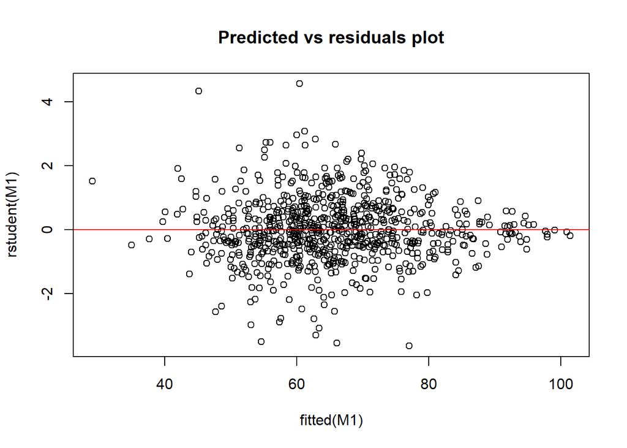

```r
plot( fitted(M1), rstudent(M1), main="Predicted vs residuals plot")
abline(a=0, b=0, col='red')
```

The residuals are mostly centered towards zero line and are randomly scattered. There are few potential outliers nearing or beyond values of 3 and -3 are noticeable but overall we can see a linear realtionship.

1. Analyze normal probability plot of residuals. Is there any evidence that the assumption of normality is not satisfied?

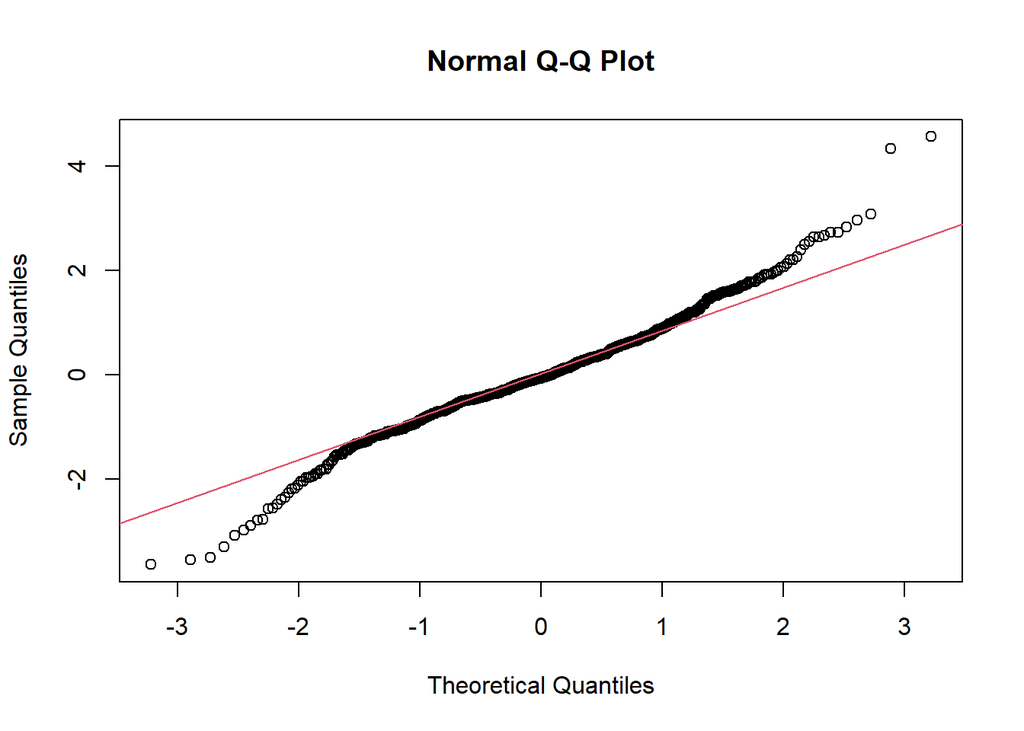

```r
qqnorm(rstudent(M1))
qqline(rstudent(M1), col = 2)
```

Here, we observe that majority of residuals are normally distributed, the deviation tails suggests that certain observations has significantly larger errors.

10. Are there any outliers or Influential Points? Compute appropriate statistics

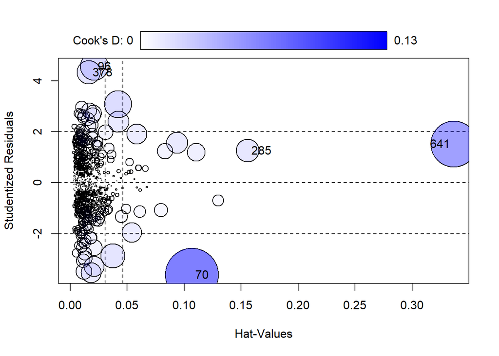

```
##       StudRes        Hat      CookD
## 70  -3.638638 0.10681301 0.12986280
## 96   4.567197 0.02112961 0.03657245
## 285  1.253147 0.15579766 0.02413313
## 378  4.332863 0.01645226 0.02557550
## 641  1.517779 0.33655563 0.09721849
```

```r
influencePlot(M1)
```

Yes there are outliers.Points 96 and 378 are outliers, as indicated by their high Studentized Residuals.

```r
summary(M1)$r.squared
```

```
## [1] 0.4430843
```

The R2 value for the final model fitted for Grad.Rate is 0.4431. This means that the predictors in the model can explain approximately 44.31% of the variation in graduation rates across universities. The remaining 55.69% of variation is due to factors not accounted for in the model or to inherent variability.

12. Draw conclusions on graduation rates based on your regression analysis. What are the most important predictors in your model? Does your model show a significant difference in graduation rates between private and public universities? Do “elite” universities have higher graduation rates?

Based on the regression analysis:

Most Important Predictors: - Significant predictors in the model include “Outstate” , “perc.alumni” , “Accept.pct” , “P.Undergrad” and “F.Undergrad” , and “Expend” . These factors notable influence on Grad Rates. Factors with larger coefficients have stronger effects.

Difference Between Private and Public Universities: - Yes, there is a statistical difference in graduation rates between public and private.The positive coefficients shows that private have higher influence than public ones. The p-value is also much smaller than 0.05.

Impact of “Elite” Universities: - The model indicates that “elite” universities do have higher graduation rates compared to non-elite universities. The positive coefficient of “Elite10Elite” supports this conclusion, implying that elite institutions generally achieve better graduation outcomes.

Conclusion: The analysis says that the significance of outstate, alumni, accept,pct, institutional type(public or private) and whether it is elite or not. Graduation rates are impacted by both private or elite status, showing that the institution has more favorable resources which supports graduation rate. However, the moderate R2 value indicates there are other unaccounted factors which affects the graduation date which model is not able to capture.

# Problem 2

1. You are asked to build a new regression model that includes the following independent variables: Elite10, Accept .pct, Outstate, perc.alumni and Expend, together with the interaction effects of elite10 with each independent variable. Fit the model and analyze if the interaction terms are significant.

```r
M2 <- lm(Grad.Rate ~ Elite10 + Accept.pct + Outstate + perc.alumni + Expend +
                 Elite10:Accept.pct + Elite10:Outstate +
                 Elite10:perc.alumni + Elite10:Expend, data = data)
summary(M2)
```

```
##
## Call:
## lm(formula = Grad.Rate ~ Elite10 + Accept.pct + Outstate + perc.alumni +
##     Expend + Elite10:Accept.pct + Elite10:Outstate + Elite10:perc.alumni +
##     Elite10:Expend, data = data)
##
## Residuals:
##     Min      1Q  Median      3Q     Max
## -53.787  -7.785  -0.400   7.769  57.177
##
## Coefficients:
##                       Estimate Std. Error t value Pr(>|t|)
## (Intercept)          5.316e+01  3.592e+00  14.801  < 2e-16 ***
## Elite10              3.763e+01  1.000e+01   3.762 0.000181 ***
## Accept.pct          -1.519e+01  4.129e+00  -3.678 0.000251 ***
## Outstate             2.296e-03  1.991e-04  11.532  < 2e-16 ***
## perc.alumni          3.505e-01  5.030e-02   6.968 6.95e-12 ***
## Expend              -9.536e-04  2.073e-04  -4.601 4.93e-06 ***
## Elite10:Accept.pct  -2.274e+01  9.822e+00  -2.315 0.020881 *
## Elite10:Outstate    -2.054e-03  5.390e-04  -3.811 0.000150 ***
## Elite10:perc.alumni -1.227e-01  1.347e-01  -0.911 0.362485
## Elite10:Expend       1.050e-03  2.889e-04   3.635 0.000297 ***
## ---
## Signif. codes:  0 '***' 0.001 '**' 0.01 '*' 0.05 '.' 0.1 ' ' 1
##
## Residual standard error: 13.12 on 767 degrees of freedom
## Multiple R-squared:  0.4234, Adjusted R-squared:  0.4167
## F-statistic: 62.58 on 9 and 767 DF,  p-value: < 2.2e-16
```

Here the regression model, including interaction terms, reveals that about 42.34% of the variation in graduation rates among universities is explained by factors such as Elite10, Accept.pct, Outstate, perc.alumni, and Expend, along with their interactions with Elite10. The model is statistically significant.

2. Simplify the model and remove interaction terms and additive terms that are not significant. Remember that additive terms included in interaction terms should not be removed. Write down the expression of the final model M2.

```r
step(M2, direction = "backward")
```

```
## Start:  AIC=4010.12
## Grad.Rate ~ Elite10 + Accept.pct + Outstate + perc.alumni + Expend +
##     Elite10:Accept.pct + Elite10:Outstate + Elite10:perc.alumni +
##     Elite10:Expend
##
##                       Df Sum of Sq    RSS    AIC
## - Elite10:perc.alumni  1    142.91 132166 4009.0
## <none>                             132023 4010.1
## - Elite10:Accept.pct   1    922.40 132945 4013.5
## - Elite10:Expend       1   2274.09 134297 4021.4
## - Elite10:Outstate     1   2499.86 134523 4022.7
##
## Step:  AIC=4008.96
## Grad.Rate ~ Elite10 + Accept.pct + Outstate + perc.alumni + Expend +
##     Elite10:Accept.pct + Elite10:Outstate + Elite10:Expend
##
##                      Df Sum of Sq    RSS    AIC
## <none>                            132166 4009.0
## - Elite10:Accept.pct  1     848.2 133014 4011.9
## - Elite10:Expend      1    2307.0 134473 4020.4
## - Elite10:Outstate    1    3601.2 135767 4027.9
## - perc.alumni         1    8785.7 140952 4057.0
```

```
##
## Call:
## lm(formula = Grad.Rate ~ Elite10 + Accept.pct + Outstate + perc.alumni +
##     Expend + Elite10:Accept.pct + Elite10:Outstate + Elite10:Expend,
##     data = data)
##
## Coefficients:
##        (Intercept)             Elite10          Accept.pct            Outstate
##          5.314e+01           3.585e+01          -1.505e+01           2.322e-03
##        perc.alumni              Expend  Elite10:Accept.pct    Elite10:Outstate
##          3.334e-01          -9.506e-04          -2.164e+01          -2.253e-03
##     Elite10:Expend
##          1.057e-03
```

```r
M2_fit = lm(Grad.Rate ~ Elite10 + Accept.pct + Outstate + perc.alumni +
    Expend + Elite10:Accept.pct + Elite10:Outstate + Elite10:Expend,
    data = data)
summary(M2_fit)
```

```
##
## Call:
## lm(formula = Grad.Rate ~ Elite10 + Accept.pct + Outstate + perc.alumni +
##     Expend + Elite10:Accept.pct + Elite10:Outstate + Elite10:Expend,
##     data = data)
##
## Residuals:
##     Min      1Q  Median      3Q     Max
## -53.724  -7.744  -0.468   7.727  57.150
##
## Coefficients:
##                      Estimate Std. Error t value Pr(>|t|)
## (Intercept)         5.314e+01  3.591e+00  14.797  < 2e-16 ***
## Elite10             3.585e+01  9.808e+00   3.655 0.000275 ***
## Accept.pct         -1.505e+01  4.126e+00  -3.647 0.000283 ***
## Outstate            2.322e-03  1.970e-04  11.786  < 2e-16 ***
## perc.alumni         3.334e-01  4.666e-02   7.145 2.09e-12 ***
## Expend             -9.506e-04  2.072e-04  -4.587 5.24e-06 ***
## Elite10:Accept.pct -2.164e+01  9.747e+00  -2.220 0.026705 *
## Elite10:Outstate   -2.253e-03  4.926e-04  -4.575 5.56e-06 ***
## Elite10:Expend      1.057e-03  2.888e-04   3.661 0.000268 ***
## ---
## Signif. codes:  0 '***' 0.001 '**' 0.01 '*' 0.05 '.' 0.1 ' ' 1
##
## Residual standard error: 13.12 on 768 degrees of freedom
## Multiple R-squared:  0.4228, Adjusted R-squared:  0.4168
## F-statistic: 70.32 on 8 and 768 DF,  p-value: < 2.2e-16
```

Model(expression):

Grad.Rate = 5.314e+01+ 3.585e+01Elite10 -1.505e+01Accept.pct + 2.322e-03Outstate + 3.334e-01perc.alumni -9.506e-04Expend -2.164e+01Elite10:Accept.pct -2.253e-03Elite10:Outstate + 1.057e-03Elite10:Expend+e

3. Analyze the parameter estimates of the fitted model and discuss how being an “Elite10” University affects the relationship between Graduation Rates and the four predictors Accept.pct, Outstate, perc.alumni and Expend.

```r
summary(M2_fit)$coefficients[ ,"Estimate"]
```

```
##        (Intercept)            Elite10         Accept.pct           Outstate
##       5.313531e+01       3.584905e+01      -1.504755e+01       2.322220e-03
##        perc.alumni             Expend Elite10:Accept.pct   Elite10:Outstate
##       3.333751e-01      -9.505835e-04      -2.163809e+01      -2.253419e-03
##     Elite10:Expend
##       1.057323e-03
```

Graduation rates are affected differently by certain factors when a university is ranked among the Elite10.

Here we observe that,the negative impact of a higher acceptance rate on graduation rates is more pronounced in elite universities Elite10:Accept.pct= -2.163809e+01 . Elite10:Outstate=-2.253419e-03 Elite universities have less of a positive impact on graduation rates from higher out-of-state tuition. Elite10:Expend=1.057323e-03 Compared to non-elite universities, elite universities benefit from higher spending per student in terms of graduation rates.

# OPTIONAL: Cross-validation

4. Apply cross-validation techniques (5-fold cross validation or divide dataset into a training and a testing set) to compute how well your final model M1 in Part 1 predicts new data. Compute the MAPE (mean absolute percentage error) statistic and discuss the results.

```r
library(caret)
set.seed(123)
ctrl <- trainControl(method = "cv", number = 5)
cv_M1 <- train(formula(M1), data = data, method = "lm", trControl = ctrl)
summary(cv_M1)
```

```
##
## Call:
## lm(formula = .outcome ~ ., data = dat)
##
## Residuals:
##     Min      1Q  Median      3Q     Max
## -45.085  -6.932  -0.775   7.325  57.598
##
## Coefficients:
##               Estimate Std. Error t value Pr(>|t|)
## (Intercept)  4.840e+01  4.621e+00  10.475  < 2e-16 ***
## Outstate     1.215e-03  2.270e-04   5.352 1.15e-07 ***
## perc.alumni  3.060e-01  4.806e-02   6.367 3.32e-10 ***
## Accept.pct  -1.778e+01  3.797e+00  -4.683 3.34e-06 ***
## P.Undergrad -1.963e-03  3.901e-04  -5.031 6.09e-07 ***
## F.Undergrad  6.631e-04  1.411e-04   4.699 3.10e-06 ***
## Room.Board   1.534e-03  5.878e-04   2.610  0.00924 **
## Expend      -4.465e-04  1.390e-04  -3.211  0.00138 **
## Personal    -1.820e-03  7.638e-04  -2.383  0.01742 *
## PrivateYes   4.770e+00  1.689e+00   2.824  0.00486 **
## PhD          8.424e-02  3.706e-02   2.273  0.02329 *
## Elite10      4.022e+00  2.002e+00   2.009  0.04492 *
## ---
## Signif. codes:  0 '***' 0.001 '**' 0.01 '*' 0.05 '.' 0.1 ' ' 1
##
## Residual standard error: 12.91 on 765 degrees of freedom
## Multiple R-squared:  0.4431, Adjusted R-squared:  0.4351
## F-statistic: 55.33 on 11 and 765 DF,  p-value: < 2.2e-16
```

```r
mape <- function(actual, predicted) {
  mean(abs((actual - predicted) / actual)) * 100
}
```

```r
mape_value <- mape(data$Grad.Rate, predict(cv_M1, newdata = data))
mape_value
```

```
## [1] 17.86888
```

A MAPE of approximately 17.86% indicates that, on average, the model’s predictions of graduation rates are off by 17.86% percentage from the actual values.

5. Apply the same cross-validation procedure and compute the MAPE statistic for the interaction model M2 computed in Part 2. Compare the predictive power of the models M1 and M2 fitted in Part 1 and Part 2.

```r
cv_M2 <- train(formula(M2_fit), data = data, method = "lm", trControl = ctrl)
summary(cv_M2)
```

```
##
## Call:
## lm(formula = .outcome ~ ., data = dat)
##
## Residuals:
##     Min      1Q  Median      3Q     Max
## -53.724  -7.744  -0.468   7.727  57.150
##
## Coefficients:
##                        Estimate Std. Error t value Pr(>|t|)
## (Intercept)           5.314e+01  3.591e+00  14.797  < 2e-16 ***
## Elite10               3.585e+01  9.808e+00   3.655 0.000275 ***
## Accept.pct           -1.505e+01  4.126e+00  -3.647 0.000283 ***
## Outstate              2.322e-03  1.970e-04  11.786  < 2e-16 ***
## perc.alumni           3.334e-01  4.666e-02   7.145 2.09e-12 ***
## Expend               -9.506e-04  2.072e-04  -4.587 5.24e-06 ***
## `Elite10:Accept.pct` -2.164e+01  9.747e+00  -2.220 0.026705 *
## `Elite10:Outstate`   -2.253e-03  4.926e-04  -4.575 5.56e-06 ***
## `Elite10:Expend`      1.057e-03  2.888e-04   3.661 0.000268 ***
## ---
## Signif. codes:  0 '***' 0.001 '**' 0.01 '*' 0.05 '.' 0.1 ' ' 1
##
## Residual standard error: 13.12 on 768 degrees of freedom
## Multiple R-squared:  0.4228, Adjusted R-squared:  0.4168
## F-statistic: 70.32 on 8 and 768 DF,  p-value: < 2.2e-16
```

```r
mape_value2 <- mape(data$Grad.Rate, predict(cv_M2, newdata = data))
mape_value2
```

```
## [1] 18.57689
```

A MAPE of approximately 18.57% indicates that, on average, the model’s predictions of graduation rates are off by 18.57% percentage from the actual values.

The model with the lower MAPE is considered to have better predictive power.Therefore Model 1 has better predictive power.